# Panoramas da biodiversidade genética do Brasil

## Atualizações…

## Atualizações

### Laboratório

### Volta ao trabalho presencial

- Organização pós pandemia
- Instalação de experimento a longo prazo (8 dias/mês)
- Treinamento de pessoal (graduação, pós)
- *Já ouviu a palavra do Hadley hoje?*
- Interação

## Atualizações

### Pesquisa

- Dados de anfíbios e répteis coletados
- Função para coleta de dados no BOLD Systems ok
- 8 dias/mês
- Treinamento de pessoal (graduação, pós)

## How to DLAB?

### A 12 Step Program to Quit Emailing Plots & Csvs

1. Basic Layout
2. Printing: Tables,Descriptice Stats, Model summaries
3. Interactive Datasets
4. Interactive Plots
5. Exporting
6. CSS basics
7. Branding (Logos, font, colors)
8. Header/Footer
9. Hosting
10. Automate-ish (render + system())
11. Replicate (render with arguments)
12. Automate or App it (cron, shiny runtime)

## How to DLAB?

### A 12 Step Program to Quit Emailing Plots & Csvs

##### 1. Basic Layout

##### 2. Printing: Tables, Descriptice Stats, Model summaries

##### 3. Interactive Datasets

##### 4. Interactive Plots

##### 5. Exporting

## 1. Basic Layout

<3 flexdashboard <3

## .Rmd + flexdashboard

### After :)

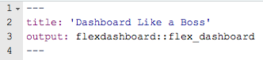

## flexdashboard layouts

### My go-to

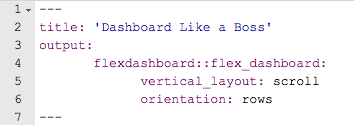

*optional*:

- vertical_layout: {scroll, fill}
- orientation: {columns, rows}

### print() is simply unacceptable

## 2. Printing Tables, Descriptive Stats & Model Summaries

## Tables, Descriptive Stats & Model Summaries

### printr summarytools::dfSummary stargazer::stargazer

## Table Printing: my go-to

### tables & descriptive stats: **printr**

### model summaries: **stargazer::stargazer**

## Model Summary & Comparisons

### stargazer::stargazer

Which model summary statistics do you wantto include in the output? Bookmark the link for later

https://rdrr.io/cran/stargazer/man/stargazer_stat_code_list.html

## 3. Interactive Datasets

## Interactive Datasets

### DT::datatable

## Datasets

### DT::datatable

- pretty printing
- flexible formatting
- column filtering
- csv download
- cell highlighting (think heatmap)

## 4. Interactive plots

### We’re not in PowerPoint anymore.

## 4. Interactive plots

### highcharter

ggplot2 will always have a place in your heart, but dashboards need more than pngs

## 4. Interactive plots

### highcharter

Other options

- *Maps*: leaflet
- *Timeseries*: dygraphs
- *ggplot2 compatible*: plotly

## Exporting

- Datasets with DT
- Highcharter Plots

## Dashboard LIKE A BOSS: pro tips

### Let your dashboard work for you

SIMPLE

- Start with a simple template & someone else’s css
- Add in the essentials or the lowest hanging fruit as you go

ORGANIZED

- *Maintain a folder* containing: css, exporting scripts, color palletes, global themes, & templates
- Keep a staging folder for exploration–*don’t make changes you won’t know how to undo*.
- Keep expensive data cleaning in a separate script (easier to introduce it later than remove it after)

EXPLORE

- Try something new (template, plots, or css) to improve the appearance & usability of each new dashboard
- Slowly work in: About page & explanations, interactive viz, exporting, logo, footer, padding/margins

## Onde me encontrar:

### github.com/rsilveirafh

1. Blog:
   - [https://rsilveirafh.netlify.app/](https://rsilveirafh.netlify.app/about.html)
2. CV:
   - All: [CV](https://github.com/rsilveirafh/blogR/blob/6013efef2292427bfbead7f12d6dcff443c1be08/Curriculum-Vitae-RRdSF.pdf)
3. LinkedIn:
   - https://www.linkedin.com/in/rsilveirafh/
4. E-mail
   - ricardodasilveira@gmail.com